# TidyTemplate

2020-10-20

# TidyTuesday

Join the R4DS Online Learning Community in the weekly #TidyTuesday event! Every week we post a raw dataset, a chart or article related to that dataset, and ask you to explore the data. While the dataset will be “tamed”, it will not always be tidy! As such you might need to apply various R for Data Science techniques to wrangle the data into a true tidy format. The goal of TidyTuesday is to apply your R skills, get feedback, explore other’s work, and connect with the greater #RStats community! As such we encourage everyone of all skills to participate!

# Load the weekly Data

Dowload the weekly data and make available in the `tt` object.

```r
tt <- tt_load("2020-10-20")
```

```
## --- Compiling #TidyTuesday Information for 2020-10-20 ----
```

```
## --- There is 1 file available ---
```

```
## --- Starting Download ---
```

```
## --- Download complete ---
```

### Readme

Take a look at the readme for the weekly data to get insight on the dataset. This includes a data dictionary, source, and a link to an article on the data.

```r
tt
```

# Glimpse Data

Take an initial look at the format of the data available.

```r
tt %>%
  map(glimpse)
```

```
## Rows: 4,970
## Columns: 7
## $ medal     <chr> "Gold", "Silver", "Bronze", "Gold", "Silver", "Bronze", "Go…
## $ beer_name <chr> "Volksbier Vienna", "Oktoberfest", "Amber Lager", "Lager at…
## $ brewery   <chr> "Wibby Brewing", "Founders Brewing Co.", "Skipping Rock Bee…
## $ city      <chr> "Longmont", "Grand Rapids", "Staunton", "Concord", "Santa R…
## $ state     <chr> "CO", "MI", "VA", "CA", "CA", "IL", "CA", "TX", "OR", "MO",…
## $ category  <chr> "American Amber Lager", "American Amber Lager", "American A…
## $ year      <dbl> 2020, 2020, 2020, 2020, 2020, 2020, 2020, 2020, 2020, 2020,…
```

```
## $beer_awards
## # A tibble: 4,970 x 7
##    medal  beer_name               brewery      city    state category       year
##    <chr>  <chr>                   <chr>        <chr>   <chr> <chr>         <dbl>
##  1 Gold   Volksbier Vienna        Wibby Brewi… Longmo… CO    American Amb…  2020
##  2 Silver Oktoberfest             Founders Br… Grand … MI    American Amb…  2020
##  3 Bronze Amber Lager             Skipping Ro… Staunt… VA    American Amb…  2020
##  4 Gold   Lager at World's End    Epidemic Al… Concord CA    American Lag…  2020
##  5 Silver Seismic Tremor          Seismic Bre… Santa … CA    American Lag…  2020
##  6 Bronze Lite Thinking           Pollyanna B… Lemont  IL    American Lag…  2020
##  7 Gold   Beachscape              Ventura Coa… Ventura CA    American Pil…  2020
##  8 Silver Imagine a World with B… Freetail Br… San An… TX    American Pil…  2020
##  9 Bronze Pilsner                 Old Town Br… Portla… OR    American Pil…  2020
## 10 Gold   Tank 7                  Boulevard B… Kansas… MO    American-Bel…  2020
## # … with 4,960 more rows
```

# Wrangle

Explore the data and process it into a nice format for plotting! Access each dataset by name by using a dollarsign after the `tt` object and then the name of the data set.

```r
data <- tt$beer_awards

state_medals <- data %>%
  mutate(state = toupper(state)) %>%
  #filter(medal == "Gold") %>%
  group_by(state, category) %>%
  count(sort = T)

state_type <- data %>%
  mutate(state = toupper(state)) %>%
  group_by(state, category) %>%
  count(sort = T) %>%
  group_by(state) %>%
  filter(category == max(category))
```

# Visualize

Using your processed dataset, create your unique visualization.

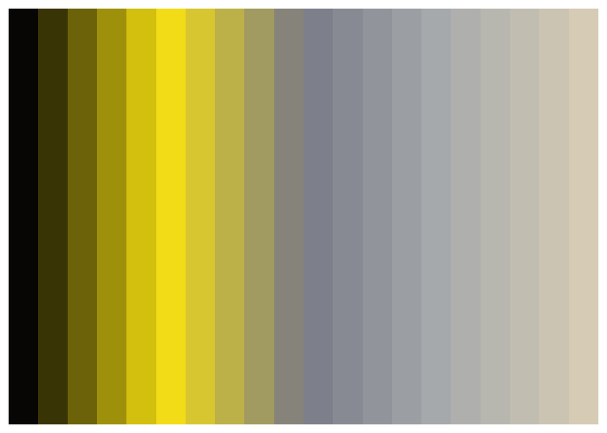

```r
color_discrete <- get_pal("Hihi")
color_continuous <- colorRampPalette(color_discrete)(20)
print_pal(color_continuous)
```

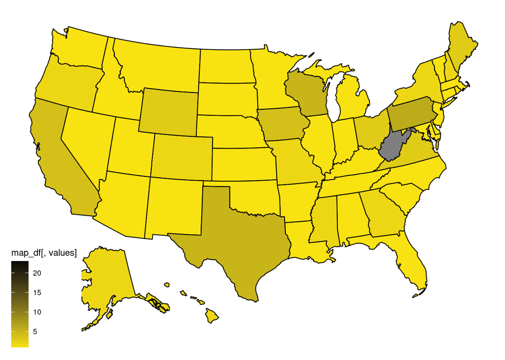

```r
plot_usmap(data = state_medals, values = "n") +
  #scale_fill_continuous(low = "#A7473A", high = "#A8B9CB")
  scale_fill_continuous(low = "#F9E211", high = "#070604")
```

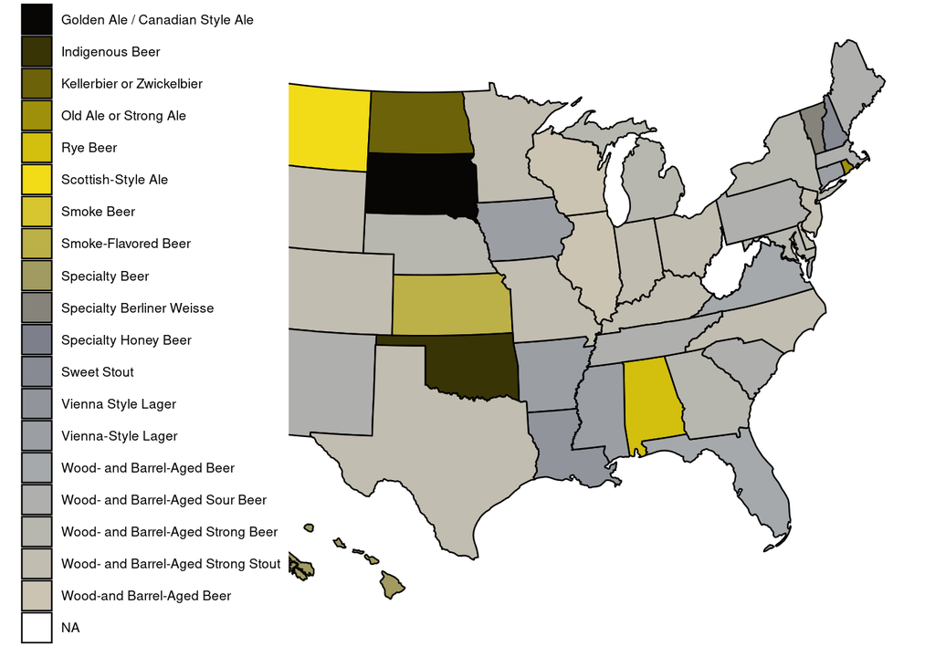

```r
plot_usmap(data = state_type, values = "category") +
  scale_fill_manual(values = color_continuous)
```

```r
state_type %>%
  str_replace(category, str_starts("Wood"),"Wood")
```

# Save Image

Save your image for sharing. Be sure to use the `#TidyTuesday` hashtag in your post on twitter!

```r
# This will save your most recent plot
ggsave(
  filename = "My TidyTuesday Plot.png",
  device = "png")
```